# Blue Wave squad report

DCDC Network · Blue Wave Analytics

Curaçao

Men’s national squad, 2026: where 26 players actually play their club football

26

Players

100%

Abroad

10

In Netherlands

0

Island league

10

Countries

82

FIFA rank

Produced from a single R Markdown file. Every number on this page is computed from **blue_wave_squad.csv** at knit time. Change the data, press Knit, and the report rewrites itself.  
**Generated:** 23 August 2026

## The question

Curaçao has a population of about 155,967 people. Its men’s national squad has 26 players in it. Of those, 26 play their club football somewhere other than the island, which is 100% of the squad, spread across 10 countries.

Not one player in this squad plays club football on Curaçao.

## Where they play

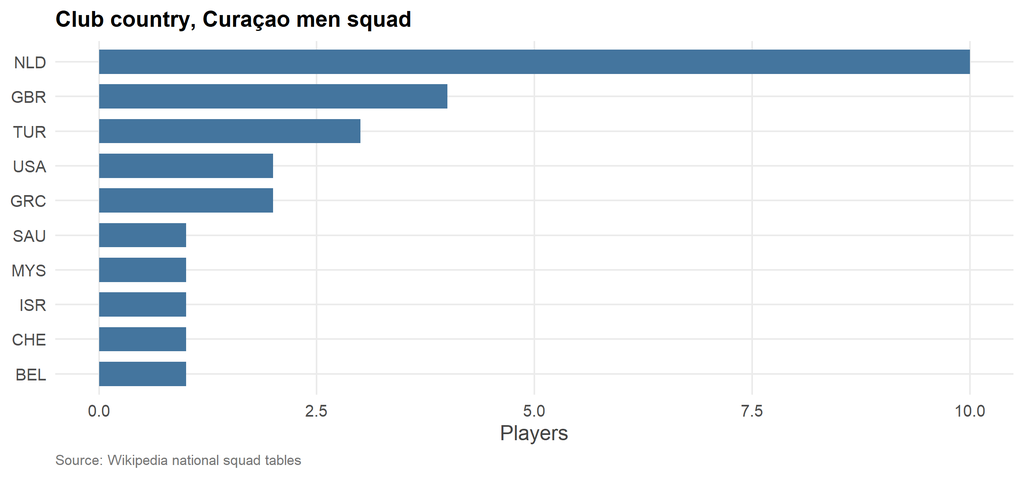

## How widely spread

Counting countries one by one buries the pattern. Grouping them into regions shows how far the squad reaches, and whether it leans on a single destination or spreads across several.

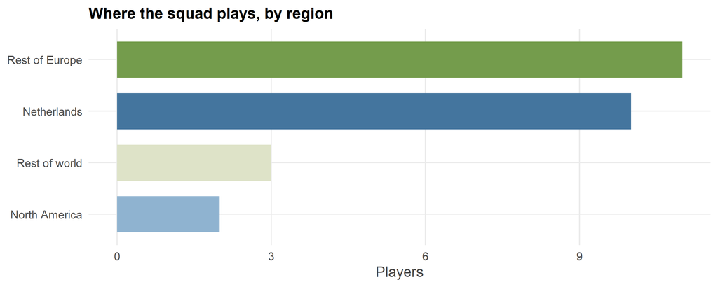

## Against the neighbours

The same table for all four ABC island squads puts this one in context.

| Island | Squad | Players | Abroad | % abroad | In Netherlands | Countries |
| --- | --- | --- | --- | --- | --- | --- |
| Curaçao | Men | 26 | 26 | 100 | 10 | 10 |
| Aruba | Men | 23 | 20 | 87 | 18 | 4 |
| Curaçao | Women | 22 | 15 | 68 | 12 | 5 |
| Aruba | Women | 23 | 15 | 65 | 14 | 3 |

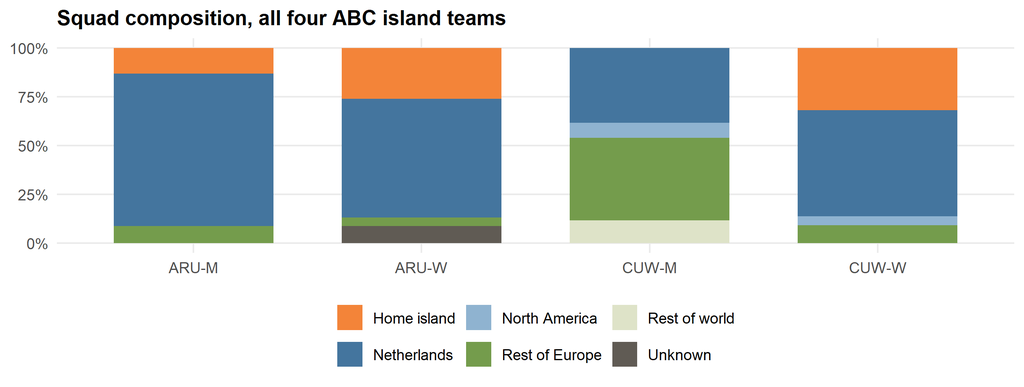

Where the sharper split actually is

Comparing the two islands on whether players are based abroad turns up very little: both send most of their squads overseas. Splitting by gender instead gives X-squared = 7.66 on 1 degree of freedom, p = 0.0056. The men’s squads are almost entirely overseas; the women’s squads keep a substantial share at home. 2 of 94 players were excluded from this test because their club could not be established.

## Punching above the population

A country’s FIFA points are, unsurprisingly, related to how many people it has. Regressing points on log population and diaspora size across 202 national associations explains about 31% of the variance. Population carries the model; the diaspora term is not statistically distinguishable from zero.

What that model gives us is a benchmark. The residual, actual points minus predicted points, says who over-performs for their size.

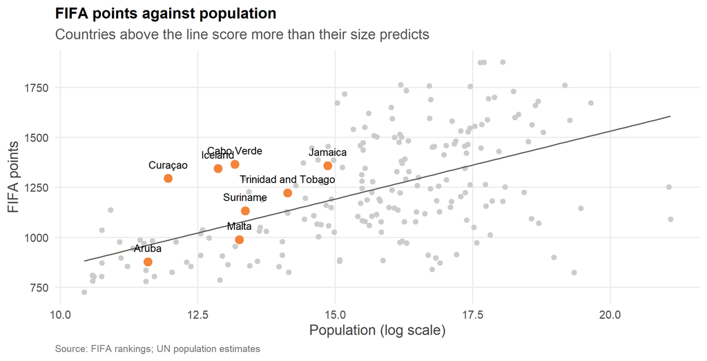

| Country | FIFA rank | Points | Predicted | Residual |
| --- | --- | --- | --- | --- |
| Curaçao | 82 | 1295 | 981 | 314 |
| Iceland | 75 | 1345 | 1043 | 302 |
| Cabo Verde | 69 | 1366 | 1075 | 291 |
| Jamaica | 71 | 1358 | 1200 | 158 |
| Trinidad and Tobago | 102 | 1223 | 1139 | 84 |
| Suriname | 125 | 1132 | 1095 | 38 |
| Malta | 161 | 988 | 1070 | -82 |
| Aruba | 189 | 877 | 966 | -89 |

Curaçao scores 1295 points, against 981 predicted for a country its size: a residual of 314.

## The squad

| Player | Position | Club | Country | Region |
| --- | --- | --- | --- | --- |
| Armando Obispo | DEF | PSV | NLD | Netherlands |
| Deveron Fonville | DEF | NEC | NLD | Netherlands |
| Joshua Brenet | DEF | Kayserispor | TUR | Rest of Europe |
| Juriën Gaari | DEF | Abha | SAU | Rest of world |
| Riechedly Bazoer | DEF | Konyaspor | TUR | Rest of Europe |
| Roshon van Eijma | DEF | A.E. Kifisia | GRC | Rest of Europe |
| Sherel Floranus | DEF | PEC Zwolle | NLD | Netherlands |
| Shurandy Sambo | DEF | Sparta Rotterdam | NLD | Netherlands |
| Brandley Kuwas | FWD | Volendam | NLD | Netherlands |
| Gervane Kastaneer | FWD | Terengganu | MYS | Rest of world |
| Jearl Margaritha | FWD | Beveren | BEL | Rest of Europe |
| Jeremy Antonisse | FWD | A.E. Kifisia | GRC | Rest of Europe |
| Jürgen Locadia | FWD | Miami FC | USA | North America |
| Kenji Gorré | FWD | Maccabi Haifa | ISR | Rest of world |
| Sontje Hansen | FWD | Middlesbrough | GBR | Rest of Europe |
| Tahith Chong | FWD | Sheffield United | GBR | Rest of Europe |
| Eloy Room | GK | Miami FC | USA | North America |
| Trevor Doornbusch | GK | VVV-Venlo | NLD | Netherlands |
| Tyrick Bodak | GK | Vitesse | NLD | Netherlands |
| Ar’jany Martha | MID | Rotherham United | GBR | Rest of Europe |
| Godfried Roemeratoe | MID | RKC Waalwijk | NLD | Netherlands |
| Juninho Bacuna | MID | Volendam | NLD | Netherlands |
| Kevin Felida | MID | Den Bosch | NLD | Netherlands |
| Leandro Bacuna (captain) | MID | Iğdır | TUR | Rest of Europe |
| Livano Comenencia | MID | Zürich | CHE | Rest of Europe |
| Tyrese Noslin | MID | Barnsley | GBR | Rest of Europe |

What this dataset cannot tell you

The squad list is scraped from the current-squad table of an English Wikipedia article. Those tables are maintained by volunteers, they lag real call-ups by weeks or months, and the four island pages are not necessarily current as of the same date. 0 players in this squad could not be placed at a club at all and are excluded from the country and region charts above.

Squad composition is also a snapshot of one call-up, not a measure of a football system. It says nothing about youth development, coaching, or the domestic game, and a report that reads it as such is reading too much into 26 rows.

Blue Wave Analytics, a DCDC Network training deliverable. Course materials CC-BY 4.0. Squad data derived from Wikipedia national-team squad tables, CC-BY-SA 4.0.